# verwerking_telemetrie_patrijs

Toon Van Daele

15-2-2022

# Verwerking telemetrie gegevens Patrijs

Dit Rmarkdown script is een ‘maquette’ voor de verwerking van de telemetriegegevens van Patrijs. In dit script worden telemetriegegevens gesimuleerd. Met een analoog script kunnen de werkelijke data ingevoerd worden.

De analyse maakt een schatting van de overleving voor 1 jaar. In de studie zal de overleving voor kortere opeenvolgende termijnen geschat worden (winteroverleving, …).

Of de schatting van alle parameters in enkele analyse kan, of het beter is voor elke parameter afzonderlijk moeten we nog bekijken.

De schatting van de parameters en de betrouwbaarheidsintervallen zijn de input voor de populatiemodellering.

Voor de individuen die niet overleven moet een assumptie gemaakt worden voor de datum waarop ze gebroed zouden hebben. -> berekening van de Saw. (zie ook Bro 1999)

## Simulatie van een dataset

We simuleren een dataset die lijkt op wat we verwachten uit de telemetriegegevevens van de Patrijs.

De gesimuleerde dataset voldoet aan een aantal karakteristieken. (nog verder te verfijnen en aan te passen)

```r
Sy <- 0.8          # Overleving (Jaar)
n_init <- 66       # Totaal aantal individuen met zenders
max_start <- 1     # Periode van start van het project en de laatste aangebrachte zender (half januari tot eind april)
p_loss_y <- 0.0001 # Kans op verlies van de zender (Jaar)
tot_days <- 365  # Totale duur van het opvolgen (dagen)
```

```r
sim1 <- sim_tel(Sy = Sy, n_init = n_init, max_start = max_start,
          p_loss_y = p_loss_y, tot_days = tot_days)
```

```r
sim1$m_time
```

```
##  [1] 1 1 1 1 1 1 1 1 1 1 1 1 1 1 1 1 1 1 1 1 1 1 1 1 1 1 1 1 1 1 1 1 1 1 1 1 1 1
## [39] 1 1 1 1 1 1 1 1 1 1 1 1 1 1 1 1 1 1 1 1 1 1 1 1 1 1 1 1
```

```r
sim1$s_time
```

```
##  [1]  878 3106   28 1092 2356  111   53  201  254 3744 1577  918 1599   88  455
## [16] 5081 1799 1541   88 2368 3374  523  402 1605 1213 1540 2737  286 1597 3254
## [31] 1411 2083  277  278  678 2483 1387   97  129 1481  756 1022 1642  599 1156
## [46] 1236 2456 2717  208  424 2057 3259 2105 2097 2317 2166  344  929  788  424
## [61] 1611 2996 2212 1614 1843    4
```

```r
sim1$l_time
```

```
##  [1] 365 365 365 365 365 365 365 365 365 365 365 365 365 365 365 365 365 365 365
## [20] 365 365 365 365 365 365 365 365 365 365 365 365 365 365 365 365 365 365 365
## [39] 365 365 365 365 365 365 365 365 365 365 365 365 365 365 365 365 365 365 365
## [58] 365 365 365 365 365 365 365 365 365
```

```r
# plot toevoegen
```

## Berekening van de survival met Kaplan-Meier

Hiervoor converteren we de data van de simulatie naar het formaat voor het survival package. In dit geval nemen we impliciet aan dat we elke dag de status opvolgen. In realiteit is dat niet zo. Nog uit te zoeken hoe dit te implementeren.

Hoe weet je wanneer een individu dood is en hoe wordt de datum bepaald? Datum van observatie? Schatting van de datum?

Bij known fate modellen (hieronder) moeten we effectief de observaties specifiëren. Misschien is dit best ook hier bij Kaplan-Meier?

```r
surv1 <- convert_to_surv(m_time = sim1$m_time,
                         s_time = sim1$s_time,
                         l_time = sim1$l_time)
surv1
```

```
## $event_time
##  [1]   3  27  52  87  87  96 110 128 200 207 253 276 277 285 343 364 364 364 364
## [20] 364 364 364 364 364 364 364 364 364 364 364 364 364 364 364 364 364 364 364
## [39] 364 364 364 364 364 364 364 364 364 364 364 364 364 364 364 364 364 364 364
## [58] 364 364 364 364 364 364 364 364 364
##
## $event_type
##  [1] 1 1 1 1 1 1 1 1 1 1 1 1 1 1 1 0 0 0 0 0 0 0 0 0 0 0 0 0 0 0 0 0 0 0 0 0 0 0
## [39] 0 0 0 0 0 0 0 0 0 0 0 0 0 0 0 0 0 0 0 0 0 0 0 0 0 0 0 0
```

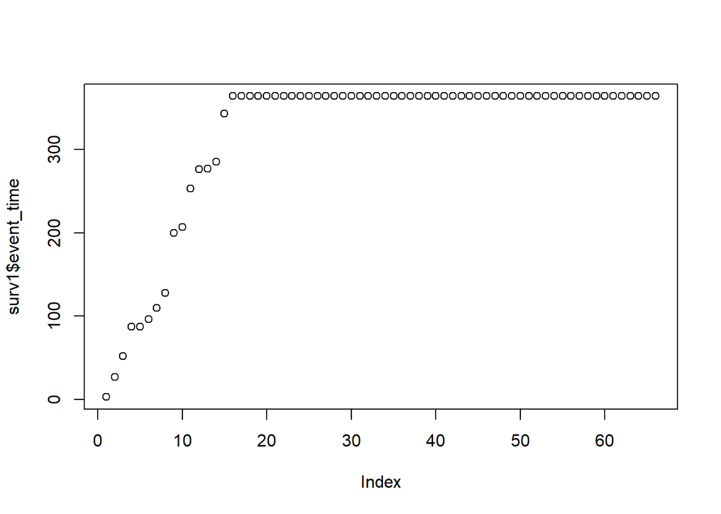

```r
plot(surv1$event_time)
```

```r
# Create survival object
km <- Surv(surv1$event_time, surv1$event_type)
km
```

```
##  [1]   3   27   52   87   87   96  110  128  200  207  253  276  277  285  343
## [16] 364+ 364+ 364+ 364+ 364+ 364+ 364+ 364+ 364+ 364+ 364+ 364+ 364+ 364+ 364+
## [31] 364+ 364+ 364+ 364+ 364+ 364+ 364+ 364+ 364+ 364+ 364+ 364+ 364+ 364+ 364+
## [46] 364+ 364+ 364+ 364+ 364+ 364+ 364+ 364+ 364+ 364+ 364+ 364+ 364+ 364+ 364+
## [61] 364+ 364+ 364+ 364+ 364+ 364+
```

```r
km_fit <- survfit(data = km, km ~ 1)
km_fit
```

```
## Call: survfit(formula = km ~ 1, data = km)
##
##       n  events  median 0.95LCL 0.95UCL
##      66      15      NA      NA      NA
```

```r
summary(km_fit)
```

```
## Call: survfit(formula = km ~ 1, data = km)
##
##  time n.risk n.event survival std.err lower 95% CI upper 95% CI
##     3     66       1    0.985  0.0150        0.956        1.000
##    27     65       1    0.970  0.0211        0.929        1.000
##    52     64       1    0.955  0.0256        0.906        1.000
##    87     63       2    0.924  0.0326        0.863        0.990
##    96     61       1    0.909  0.0354        0.842        0.981
##   110     60       1    0.894  0.0379        0.823        0.971
##   128     59       1    0.879  0.0402        0.803        0.961
##   200     58       1    0.864  0.0422        0.785        0.951
##   207     57       1    0.848  0.0441        0.766        0.940
##   253     56       1    0.833  0.0459        0.748        0.928
##   276     55       1    0.818  0.0475        0.730        0.917
##   277     54       1    0.803  0.0490        0.713        0.905
##   285     53       1    0.788  0.0503        0.695        0.893
##   343     52       1    0.773  0.0516        0.678        0.881
```

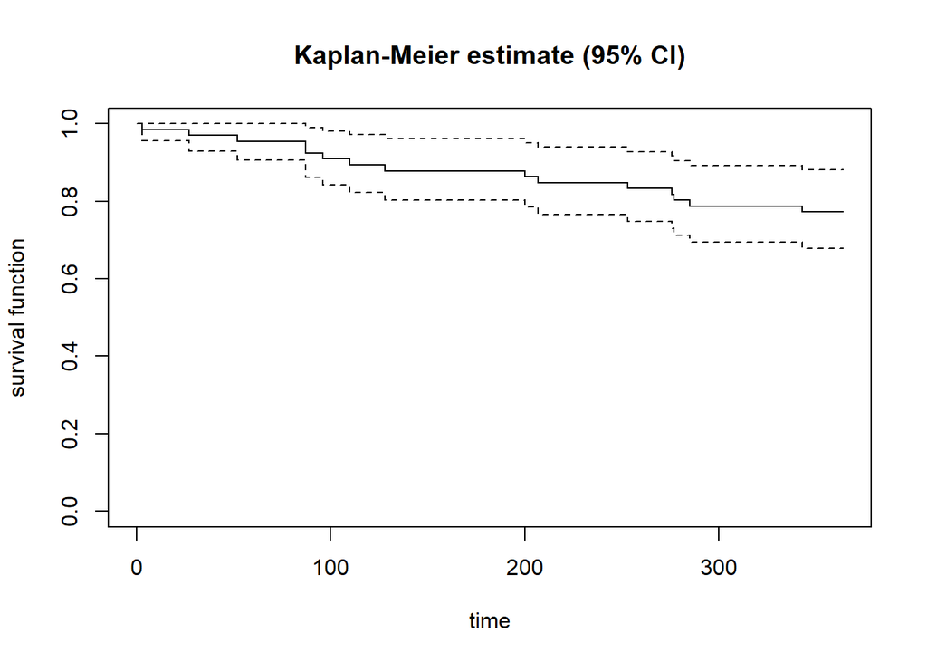

```r
plot(km_fit, main = "Kaplan-Meier estimate (95% CI)",
     xlab = "time", ylab = "survival function")
```

```r
cat(tail(summary(km_fit)$surv, 1), "(", tail(summary(km_fit)$lower, 1), "-",
      tail(summary(km_fit)$upper, 1), ")")
```

```
## 0.7727273 ( 0.6779594 - 0.8807422 )
```

## Schatting van overleving met ‘known fate model’ (RMark)

Hiervoor moeten we eerst de data in de vorm van een life history zetten. Een vector met opeenvolging van LDLDLDLD…(L = live, D = dead) een rij per individu.

Voor de life history hebben de effectieve timing van de observaties nodig. We stellen hier een vast interval voor de observaties. Later kan dit aangepast worden aan de werkelijke tijd van observatie.

Confirmeren van dood: Er zijn er die dood gevonden worden, soms afgevallen zender in omstandigheden die vrij zeker gelinked zijn aan predatie.

Af en toe verdwijnen er individuen gedurende enkele weken.

Observaties: elke week, in de zomer frequenter. Overlijden steeds op de datum van de observatie.

Probleem voor de overleving tot broeden -> einddatum verschilt!

```r
it <- 7 # time interval between observations (days)
# An extra observation is added for the last day of the study
obs <- c(seq(from = 1, to = tot_days - it, by = it), tot_days)
obs
```

```
##  [1]   1   8  15  22  29  36  43  50  57  64  71  78  85  92  99 106 113 120 127
## [20] 134 141 148 155 162 169 176 183 190 197 204 211 218 225 232 239 246 253 260
## [39] 267 274 281 288 295 302 309 316 323 330 337 344 351 358 365
```

```r
df_ch1 <- convert_to_RMark(obs = obs, m_time = sim1$m_time,
                           s_time = sim1$s_time, l_time = sim1$l_time)
df_ch1
```

```
##                                                                                                            ch
## 1  0010101010101010101010101010101010101010101010101010101010101010101010101010101010101010101010101010101010
## 2  0010101010101010101010101010101010101010101010101010101010101010101010101010101010101010101010101010101010
## 3  1010101011000000000000000000000000000000000000000000000000000000000000000000000000000000000000000000000000
## 4  0010101010101010101010101010101010101010101010101010101010101010101010101010101010101010101010101010101010
## 5  0010101010101010101010101010101010101010101010101010101010101010101010101010101010101010101010101010101010
## 6  1010101010101010101010101010101011000000000000000000000000000000000000000000000000000000000000000000000000
## 7  1010101010101010110000000000000000000000000000000000000000000000000000000000000000000000000000000000000000
## 8  1010101010101010101010101010101010101010101010101010101010110000000000000000000000000000000000000000000000
## 9  1010101010101010101010101010101010101010101010101010101010101010101010101011000000000000000000000000000000
## 10 0010101010101010101010101010101010101010101010101010101010101010101010101010101010101010101010101010101010
## 11 0010101010101010101010101010101010101010101010101010101010101010101010101010101010101010101010101010101010
## 12 0010101010101010101010101010101010101010101010101010101010101010101010101010101010101010101010101010101010
## 13 0010101010101010101010101010101010101010101010101010101010101010101010101010101010101010101010101010101010
## 14 1010101010101010101010101011000000000000000000000000000000000000000000000000000000000000000000000000000000
```

[output cut: 52 more lines]

```r
# RMark - Known fate model
# Process data
processed <- process.data(df_ch1, model = "Known")

# Create default design data
ddl <- make.design.data(processed)

#  Define range of models for S
S.dot = list(formula = ~1)
#S.time = list(formula = ~time)

# Create model list and run assortment of models
model.list = create.model.list("Known")
results <- mark.wrapper(model.list, data = processed, ddl = ddl,
                        invisible = FALSE,threads = 1)
```

```
##
## S.dot
```

```
##
## Output summary for Known model
## Name : S(~1)
##
## Npar :  1
## -2lnL:  189.0941
## AICc :  191.0955
##
## Beta
##               estimate        se      lcl      ucl
## S:(Intercept) 5.300648 0.2588421 4.793317 5.807978
##
##
## Real Parameter S
##          2         3         4         5         6         7         8
##  0.9950364 0.9950364 0.9950364 0.9950364 0.9950364 0.9950364 0.9950364
##          9        10        11        12        13        14        15
##  0.9950364 0.9950364 0.9950364 0.9950364 0.9950364 0.9950364 0.9950364
##         16        17        18        19        20        21        22
##  0.9950364 0.9950364 0.9950364 0.9950364 0.9950364 0.9950364 0.9950364
##         23        24        25        26        27        28        29
##  0.9950364 0.9950364 0.9950364 0.9950364 0.9950364 0.9950364 0.9950364
##         30        31        32        33        34        35        36
##  0.9950364 0.9950364 0.9950364 0.9950364 0.9950364 0.9950364 0.9950364
##         37        38        39        40        41        42        43
##  0.9950364 0.9950364 0.9950364 0.9950364 0.9950364 0.9950364 0.9950364
##         44        45        46        47        48        49        50
##  0.9950364 0.9950364 0.9950364 0.9950364 0.9950364 0.9950364 0.9950364
##         51        52        53        54
##  0.9950364 0.9950364 0.9950364 0.9950364
```

```r
results
```

```
##   model npar     AICc DeltaAICc weight Deviance
## 1 S(~1)    1 191.0955         0      1 42.65111
```

```r
results[[1]]$results$real
```

```
##             estimate        se       lcl       ucl fixed note
## S g1 a1 t2 0.9950364 0.0012784 0.9917831 0.9970055
```

```r
S_kf <- (results[[1]]$results$real$estimate)^length(obs)
S_kf_lcl <- (results[[1]]$results$real$lcl)^length(obs)
S_kf_ucl <- (results[[1]]$results$real$ucl)^length(obs)
```

```r
cat(S_kf, "(", S_kf_lcl, "-", S_kf_ucl, ")")
```

```
## 0.7681841 ( 0.645781 - 0.8530419 )
```